# Digital media supporting literacy learning in children with communicative and cognitive disabilities

Lisa Palmqvist

1,2  
lisa.palmqvist@liu.se

Emil Holmer

1,2

More authors to be added

1, 2, 3,4

22 November, 2022

Abstract

# Results with IQ

The participants were randomly selected on school level to different intervention groups. This was done to try to match the groups on IQ. Nevertheless, the IQ in the groups differed somewhat, *H*(3) = 4.795, *p* =.187. Facon, Magis, and Belmont (2011) proposed groups be equated with an α-level of *p* > 0.50. The Animega-is group had a significantly higher IQ ( *m* =52.057; *sd* =14.713) compared to the Comparison group ( *m* =44.609; *sd* =7.709), *p* =.0015, the ALL group ( *m* =46.118; *sd* =11.102),  
*p* <.001, and the combination group ( *m* =48.73; *sd* =14.619), *p* =.0027. Thus, IQ was used as a control variable in all outcome variables.

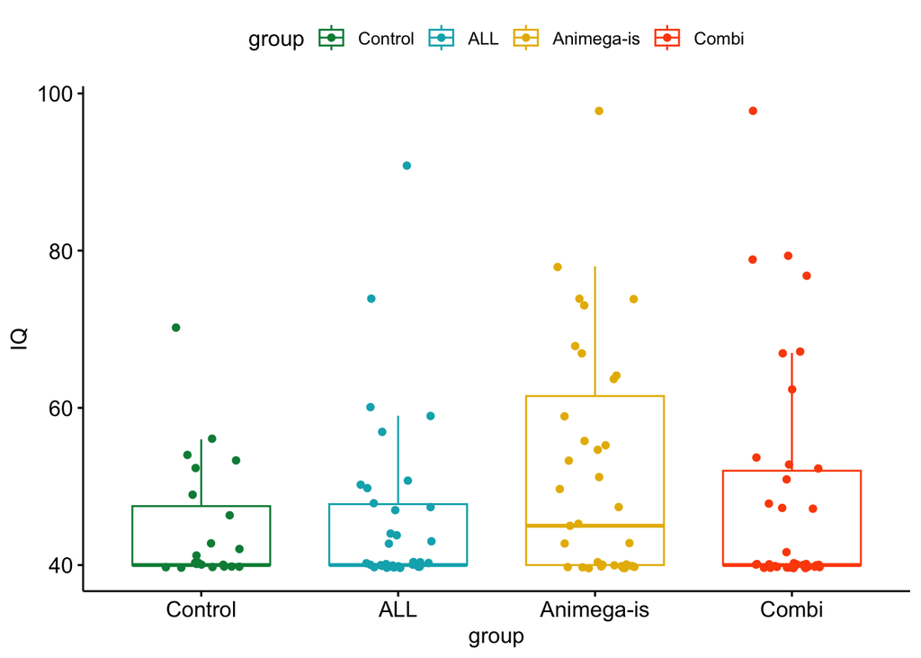

## Training time

The participants were instructed to train for a total of 18 hours (36 sessions for 30 minutes, three days a week for a 12-week period). The teachers were instructed to adapt the length of the training sessions after the need of the student. That is, if the student could not sit for a full 30 minute session the teacher was encouraged to have shorter sessions but more often than three times a week. On average the participants trained for 384.932 (*sd* =194.118) minutes (6.416 (*sd* =3.235) hours). There was no difference on training time between the three intervention groups (*H*(2) = 0.572, *p* =.751 ).

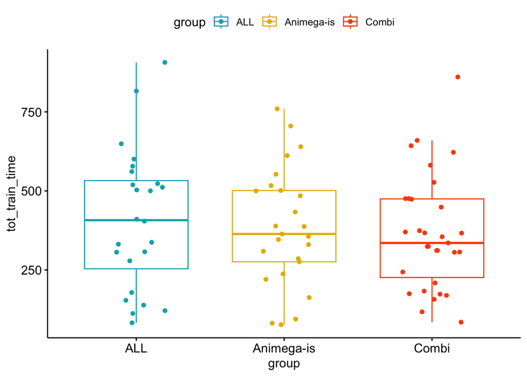

## Phonological awareness

### Hypothesis 1a: Training phonemic reading strategies improves phonological awareness.

There was almost a significant interaction between time and the intervention on phonemic reading, the group training phonemic strategies improved more than the comparison group ($\hat{\beta} = 0.01$, 95% CI $[0.00, 0.02]$, $t(354.67) = 1.91$, $p = .057$).

### Hypothesis 1b: Training comprehension-based reading strategies improves phonological awareness.

There was no significant interaction between time and intervention for the comprehension-based reading strategy on PA ($\hat{\beta} = 0.00$, 95% CI $[-0.01, 0.01]$, $t(355.40) = 0.48$, $p = .629$).

### Hypothesis 3: The combined training is more effective than either intervention on its own.

There was a significant interaction between the combined group and the other two intervention groups, ($\hat{\beta} = 0.01$, 95% CI $[0.00, 0.02]$, $t(355.72) = 2.83$, $p = .005$), the combined training improved PA over time more than the other two intervention groups.

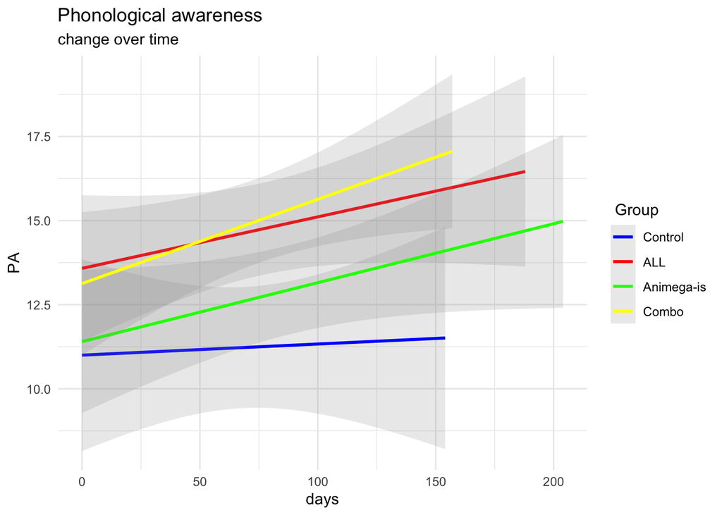

[figure not shown]

## Exploratory analyses

### Effect of IQ

There was a significant main effect on IQ ($\hat{\beta} = 1.69$, 95% CI $[0.37, 3.02]$, $t(156.06) = 2.51$, $p = .013$), indicating that higher IQ results in higher PA at T1. Moreover, there was a significant interaction between time and IQ ($\hat{\beta} = 0.01$, 95% CI $[0.00, 0.01]$, $t(357.34) = 2.46$, $p = .014$), indicating that the participants with the highest IQ benefited the most from the intervention. However, the benefit of the combined training over the two other intervention types remained ($\hat{\beta} = 0.01$, 95% CI $[0.00, 0.02]$, $t(355.72) = 2.83$, $p = .005$)

The results from the PA models can be seen in Table @ref(tab:PA-table).

|  | PA |  |  |  |
| --- | --- | --- | --- | --- |
| Predictors | Estimates | CI | p | df |
| (Intercept) | 12.45 | 11.13 – 13.77 | **<0.001** | 469.00 |
| days | 0.01 | 0.01 – 0.02 | **<0.001** | 469.00 |
| contrast 1vs2 | 1.66 | -0.51 – 3.84 | 0.134 | 469.00 |
| contrast 1vs3 | -1.17 | -3.39 – 1.05 | 0.301 | 469.00 |
| contrast 4vs23 | 0.48 | -1.70 – 2.67 | 0.663 | 469.00 |
| IQ scale | 1.69 | 0.37 – 3.02 | **0.012** | 469.00 |
| days * contrast 1vs2 | 0.01 | -0.00 – 0.02 | 0.057 | 469.00 |
| days * contrast 1vs3 | 0.00 | -0.01 – 0.01 | 0.628 | 469.00 |
| days * contrast 4vs23 | 0.01 | 0.00 – 0.02 | **0.005** | 469.00 |
| days * IQ scale | 0.01 | 0.00 – 0.01 | **0.014** | 469.00 |
| Random Effects |  |  |  |  |
| σ<sup>2</sup> | 12.18 |  |  |  |
| τ<sub>00</sub> <sub>id</sub> | 46.87 |  |  |  |
| ICC | 0.79 |  |  |  |
| N <sub>id</sub> | 128 |  |  |  |
| Observations | 481 |  |  |  |
| Marginal R<sup>2</sup> / Conditional R<sup>2</sup> | 0.113 / 0.817 |  |  |  |

## Word reading

### Hypothesis 1a: Training phonemic reading strategies improves word reading.

There was not a significant interaction between time and the intervention on phonemic-based reading ($\hat{\beta} = 0.06$, 95% CI $[-0.04, 0.17]$, $t(125.21) = 1.17$, $p = .245$).

### Hypothesis 1b: Training comprehension-based reading strategies improves word awareness.

There was no significant interaction between time and intervention for the comprehension-based reading strategy on word reading ($\hat{\beta} = -0.02$, 95% CI $[-0.12, 0.08]$, $t(112.77) = -0.38$, $p = .707$).

### Hypothesis 3: The combined training is more effective than either intervention on its own.

There was a not significant interaction between the combined group and the other two intervention groups, ($\hat{\beta} = -0.01$, 95% CI $[-0.12, 0.10]$, $t(161.69) = -0.17$, $p = .865$).

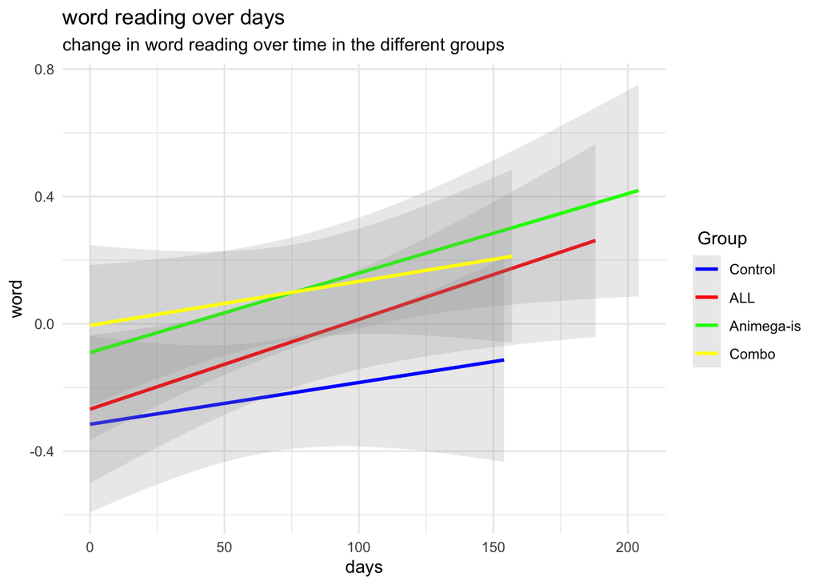

## Exploratory analyses

### Effect of IQ

There was a significant main effect on IQ ($\hat{\beta} = 0.16$, 95% CI $[0.01, 0.30]$, $t(128.40) = 2.15$, $p = .034$), indicating that higher IQ results in higher word reading at T1. Moreover, there was a significant interaction between time and IQ ($\hat{\beta} = 0.06$, 95% CI $[0.00, 0.13]$, $t(114.71) = 1.99$, $p = .049$), indicating that the participants with the highest IQ improved most over the training period regardless of intervention condition (including control).

The results from the word models can be seen in Table @ref(tab:word-table).

|  | word |  |  |  |
| --- | --- | --- | --- | --- |
| Predictors | Estimates | CI | p | df |
| (Intercept) | -0.18 | -0.32 – -0.04 | **0.014** | 463.00 |
| days | 0.20 | 0.14 – 0.27 | **<0.001** | 463.00 |
| contrast 1vs2 | 0.01 | -0.23 – 0.24 | 0.939 | 463.00 |
| contrast 1vs3 | 0.09 | -0.14 – 0.33 | 0.435 | 463.00 |
| contrast 4vs23 | 0.14 | -0.09 – 0.38 | 0.228 | 463.00 |
| IQ scale | 0.16 | 0.01 – 0.30 | **0.032** | 463.00 |
| days * contrast 1vs2 | 0.06 | -0.04 – 0.17 | 0.243 | 463.00 |
| days * contrast 1vs3 | -0.02 | -0.12 – 0.08 | 0.706 | 463.00 |
| days * contrast 4vs23 | -0.01 | -0.12 – 0.10 | 0.864 | 463.00 |
| days * IQ scale | 0.06 | 0.00 – 0.13 | **0.047** | 463.00 |
| Random Effects |  |  |  |  |
| σ<sup>2</sup> | 0.15 |  |  |  |
| τ<sub>00</sub> <sub>id</sub> | 0.53 |  |  |  |
| τ<sub>11</sub> <sub>id.scale(days, center = FALSE)</sub> | 0.02 |  |  |  |
| ρ<sub>01</sub> <sub>id</sub> | 0.48 |  |  |  |
| ICC | 0.80 |  |  |  |
| N <sub>id</sub> | 127 |  |  |  |
| Observations | 477 |  |  |  |
| Marginal R<sup>2</sup> / Conditional R<sup>2</sup> | 0.087 / 0.819 |  |  |  |

# Sentence reading

### Hypothesis 1a: Training phonemic reading strategies improves sentence reading.

There was not a significant interaction between time and the intervention on phonemic training on sentence reading ($\hat{\beta} = 0.19$, 95% CI $[-0.24, 0.61]$, $z = 0.86$, $p = .392$).

### Hypothesis 1b: Training comprehension-based reading strategies improves sentence awareness.

There was no significant interaction between time and intervention for the comprehension-based reading strategy on sentence reading ($\hat{\beta} = -0.09$, 95% CI $[-0.51, 0.32]$, $z = -0.44$, $p = .659$).

### Hypothesis 3: The combined training is more effective than either intervention on its own.

There was a not significant interaction between the combined group and the other two intervention groups, ($\hat{\beta} = -0.12$, 95% CI $[-0.63, 0.39]$, $z = -0.47$, $p = .641$).

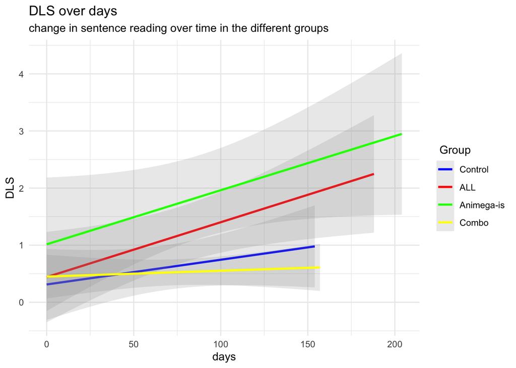

## Exploratory analyses

### Effect of IQ

The results from the word models can be seen in Table @ref(tab:DLS-table).

|  | DLS |  |  | DLS |  |  |
| --- | --- | --- | --- | --- | --- | --- |
| Predictors | Incidence Rate Ratios | CI | p | Incidence Rate Ratios | CI | p |
| (Intercept) | 0.07 | 0.03 – 0.14 | **<0.001** | 0.03 | 0.01 – 0.10 | **<0.001** |
| days | 1.72 | 1.27 – 2.33 | **<0.001** | 3.22 | 1.66 – 6.26 | **0.001** |
| contrast 1vs2 | 1.07 | 0.45 – 2.55 | 0.877 |  |  |  |
| contrast 1vs3 | 1.38 | 0.59 – 3.24 | 0.463 |  |  |  |
| contrast 4vs23 | 0.84 | 0.34 – 2.08 | 0.711 |  |  |  |
| days * contrast 1vs2 | 1.20 | 0.79 – 1.85 | 0.392 |  |  |  |
| days * contrast 1vs3 | 0.91 | 0.60 – 1.38 | 0.659 |  |  |  |
| days * contrast 4vs23 | 0.89 | 0.53 – 1.47 | 0.641 |  |  |  |
| IQ scale |  |  |  | 1.65 | 0.88 – 3.10 | 0.117 |
| IQ scale * days |  |  |  | 1.20 | 0.91 – 1.58 | 0.188 |
| Random Effects |  |  |  |  |  |  |
| σ<sup>2</sup> | 2.42 |  |  | 2.49 |  |  |
| τ<sub>00</sub> | 5.42 <sub>id</sub> |  |  | 7.94 <sub>id</sub> |  |  |
| τ<sub>11</sub> | 0.40 <sub>id.scale(days, center = FALSE)</sub> |  |  | 0.52 <sub>id.scale(days, center = FALSE)</sub> |  |  |
| ρ<sub>01</sub> |  |  |  | -0.74 <sub>id</sub> |  |  |
| ICC | 0.69 |  |  | 0.71 |  |  |
| N | 134 <sub>id</sub> |  |  | 127 <sub>id</sub> |  |  |
| Observations | 488 |  |  | 476 |  |  |
| Marginal R<sup>2</sup> / Conditional R<sup>2</sup> | 0.034 / 0.702 |  |  | 0.102 / 0.739 |  |  |

# Explorative analyses

## Letter-sound recognition

### Hypothesis 1a: Training phonemic reading strategies improves letter-sound recognition.

There was a significant interaction between time and the intervention on phonemic training on letter-sound recognition ($\hat{\beta} = 0.41$, 95% CI $[0.10, 0.72]$, $t(119.89) = 2.62$, $p = .010$).

### Hypothesis 1b: Training comprehension-based reading strategies improves sletter-sound recognition.

There was no significant interaction between time and intervention for the comprehension-based reading strategy on letter-sound recognition ($\hat{\beta} = 0.10$, 95% CI $[-0.21, 0.41]$, $t(109.59) = 0.64$, $p = .526$).

### Hypothesis 3: The combined training is more effective than either intervention on its own.

There was a not significant interaction between the combined group and the other two intervention groups, ($\hat{\beta} = 0.07$, 95% CI $[-0.26, 0.39]$, $t(154.36) = 0.39$, $p = .695$).

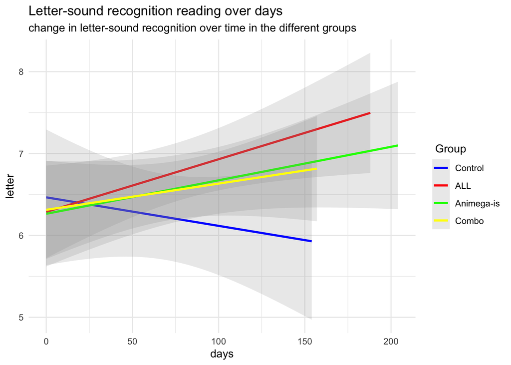

### Effect of IQ

The results from the word models can be seen in Table @ref(tab:letter-table).

|  | letter |  |  |  |
| --- | --- | --- | --- | --- |
| Predictors | Estimates | CI | p | df |
| (Intercept) | 6.30 | 5.87 – 6.72 | **<0.001** | 468.00 |
| days | 0.24 | 0.05 – 0.43 | **0.015** | 468.00 |
| contrast 1vs2 | 0.00 | -0.70 – 0.71 | 0.992 | 468.00 |
| contrast 1vs3 | -0.27 | -0.99 – 0.45 | 0.462 | 468.00 |
| contrast 4vs23 | -0.04 | -0.74 – 0.67 | 0.920 | 468.00 |
| IQ scale | 0.51 | 0.08 – 0.93 | **0.021** | 468.00 |
| days * contrast 1vs2 | 0.41 | 0.10 – 0.72 | **0.009** | 468.00 |
| days * contrast 1vs3 | 0.10 | -0.21 – 0.41 | 0.525 | 468.00 |
| days * contrast 4vs23 | 0.07 | -0.26 – 0.40 | 0.694 | 468.00 |
| days * IQ scale | -0.11 | -0.30 – 0.08 | 0.261 | 468.00 |
| Random Effects |  |  |  |  |
| σ<sup>2</sup> | 1.23 |  |  |  |
| τ<sub>00</sub> <sub>id</sub> | 4.94 |  |  |  |
| τ<sub>11</sub> <sub>id.scale(days, center = FALSE)</sub> | 0.24 |  |  |  |
| ρ<sub>01</sub> <sub>id</sub> | -0.80 |  |  |  |
| ICC | 0.76 |  |  |  |
| N <sub>id</sub> | 129 |  |  |  |
| Observations | 482 |  |  |  |
| Marginal R<sup>2</sup> / Conditional R<sup>2</sup> | 0.048 / 0.767 |  |  |  |

# marginal and conditional R2

A marginal R2 close to zero tells us that the fixed effects aren’t explaining much variation, and a conditional R2 close to 1 tells us that most of that unexplained variation is between groups (people) rather than between observations within groups (people). So, for example, if the context was a longitudinal cohort study, we wouldn’t expect to improve our model much by collecting more data on characteristics/measures that mainly vary within people, but instead should find characteristics that mainly vary between people.

# Results summary

# Discussion

# References

Facon, Bruno, David Magis, and John M. Belmont. 2011. “Beyond matching on the mean in developmental disabilities research.” *Research in Developmental Disabilities* 32 (6): 2134–47. https://doi.org/10.1016/j.ridd.2011.07.029.